# BP-WMH-VaD

Seongwon Hwang

30-09-2026

# Load packages and functions

```r
# Installed the following packages by running:
# > conda env create -f env.yml
# > conda activate BP-WMH-VaD

suppressWarnings(suppressMessages({
  if (requireNamespace("dplyr", quietly = TRUE)) library(dplyr)
  if (requireNamespace("readr", quietly = TRUE)) library(readr)
  if (requireNamespace("ggplot2", quietly = TRUE)) library(ggplot2)
  if (requireNamespace("cowplot", quietly = TRUE)) library(cowplot)
  if (requireNamespace("MendelianRandomization", quietly = TRUE)) {
    library(MendelianRandomization)
  }
}))
```

# Download data

Public files (European WMH, FinnGen VaD, Bellenguez AD, 1000 Genomes EUR, PLINK):

```r
# python scripts/download_public_gwas.py
```

Evangelou et al. 2018 SBP, DBP, and pulse-pressure discovery GWAS are not on the GWAS Catalog FTP. Place `data/GWAS/Evangelou_30224653_{SBP,DBP,PP}.txt.gz` after requesting them from the corresponding authors / ICBP, or after downloading OpenGWAS `ieu-b-38` (SBP) and `ieu-b-39` (DBP). See `data/README.md`.

Japanese BioBank Japan and JPSC-AD files:

```r
# powershell -File Japanese_BP_WMH_GWMR/scripts/download_gwas.ps1
```

Instrument-level tables for the paper MR are already in `data/RData/` and `Japanese_BP_WMH_GWMR/analysis_history/20260830_multi_exposure_jpsc_wmh/results/harmonized_instruments.tsv`. Rebuild from GWAS only if needed:

```r
# python scripts/build_gwas_ivs_1kg_clump.py --only all
```

# Primary two-step (APOE excluded)

A priori *APOE* window, GRCh37 chr19:44,909,039-45,912,650. Primary estimator: multiplicative random-effects IVW. Scale: WMH SD per 10 mm Hg; VaD odds ratio per 10 mm Hg or per WMH SD.

```r
apoe_lo <- 44909039
apoe_hi <- 45912650
in_apoe <- function(chrom, pos) {
  ch <- gsub("^chr", "", as.character(chrom))
  ch == "19" & !is.na(pos) & pos >= apoe_lo & pos <= apoe_hi
}

exp_iv <- readr::read_tsv("data/RData/DBP_gwas_ivs.tsv", show_col_types = FALSE)
pair <- readr::read_tsv("data/RData/WMH_DBP_gwas_iv.tsv", show_col_types = FALSE)
dat <- dplyr::left_join(
  pair,
  dplyr::transmute(exp_iv, snp, chrom_hg19, pos_hg19),
  by = "snp"
)
dat <- dat[!in_apoe(dat$chrom_hg19, dat$pos_hg19), ]
mr_in <- MendelianRandomization::mr_input(
  bx = dat$bx, bxse = dat$bxse,
  by = dat$beta, byse = dat$se, snps = dat$snp
)
ivw <- MendelianRandomization::mr_ivw(mr_in, model = "random")
print(c(
  n = nrow(dat),
  beta_per_10mmHg = 10 * ivw$Estimate,
  lo = 10 * ivw$CILower,
  hi = 10 * ivw$CIUpper,
  p = ivw$Pvalue
))
```

```
##               n beta_per_10mmHg              lo              hi               p
##    4.540000e+02    1.755892e-01    1.149346e-01    2.362438e-01    1.395779e-08
```

Full two-step, Steiger, AD check, Japanese three-method MR, PP, residual path, 17q leave-out, and leave-one-out:

```r
# Rscript analysis_history/20260830_twostep_bp_wmh_vad_apoe_excl/scripts/run_twostep_bp_wmh_vad.R
# Rscript scripts/run_jp_bp_wmh_three_methods.R
# Rscript scripts/run_pp_primary_mr.R
# python analysis_history/20260830_bp_indep_wmh_vad/scripts/lookup_wmh_iv_bp.py
# Rscript analysis_history/20260830_bp_indep_wmh_vad/scripts/run_bp_indep_wmh_vad.R
# python analysis_history/20260830_r13_bp_indep_wmh_vad_bryois/scripts/lookup_r13_vad.py
# Rscript analysis_history/20260830_r13_bp_indep_wmh_vad_bryois/scripts/run_r13_mr.R
# Rscript analysis_history/20260830_17q2131_h1h2_pleiotropy_ivw/scripts/01_ivw_with_without.R
# Rscript analysis_history/20260915_loo_wmh_vad_apoe_excl/scripts/run_loo_wmh_vad_n16.R
# Rscript analysis_history/20260915_path_robustness_loo_ad_overlap/scripts/run_path_robustness.R
```

# Figures

Paper displays. Numbers are the locked estimates used in the manuscript.

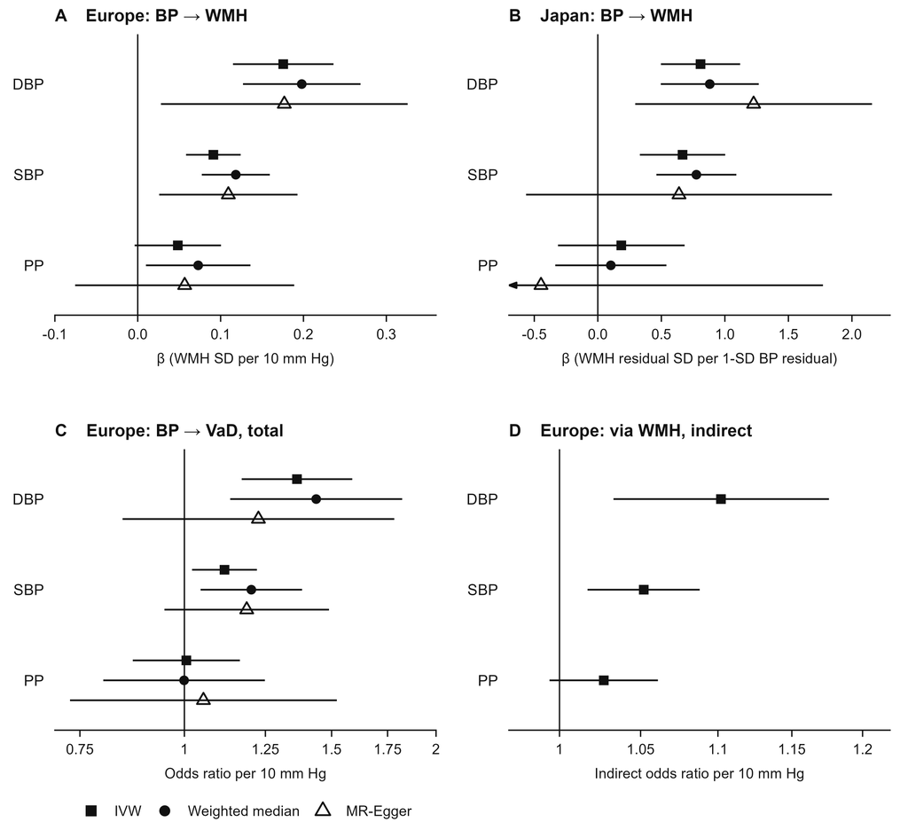

Figure 2. Primary MR.

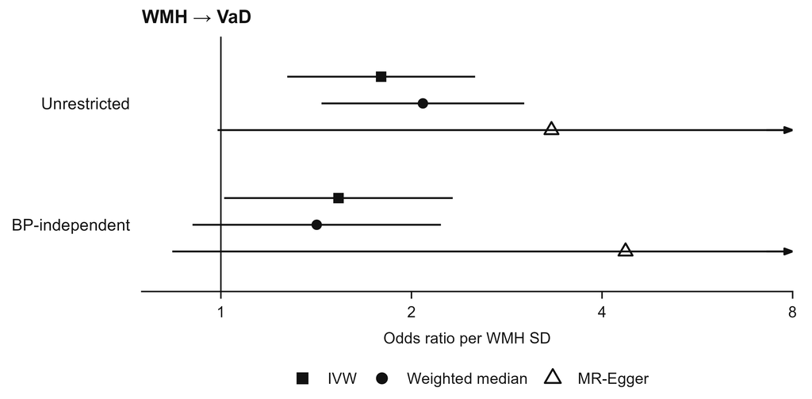

Figure S1. Residual WMH to VaD (FinnGen R13).

```r
dir.create("manuscript/figures", recursive = TRUE, showWarnings = FALSE)
source("scripts/plot_main_figures_stroke_bp_wmh_vad.R")
```